# CodeRed_Module7

Liz Asprinio, Tingwei Hu, James Kim, Justin Lau

2022-11-27

# Introduction

The muscle force-length relationship is governed by several factors. One aspect is the number of crossbridges formed in the regions of actin-myosin overlap of a sarcomere, which is directly related to the maximum amount of isometric force that can be produced by the muscle. Another aspect is mechanical advantage, the ratio between input and output force:
$$MA = L_i/L_o$$
Greater mechanical advantage is described by a smaller ratio, or moving a load using a relatively small force. In the human body, this concept is illustrated by bones and joints acting as levers and pivots to minimize the force required by muscles to move a load. The arm is a lever and has a mechanical advantage of 0.2. However, the insertion angle of the muscles changes as the forearm flexes, which also affects to the output force. Although this complicates the study of force-length relationships, research has shown that output force is sufficient to determine force-length relationships in input muscles (Rassier, MacIntosh, and Herzog (1999)). In this project, the force-length relationship of input muscles in the human arm and their response to fatigue will be studied. First, human forearm flexors will undertake maximum voluntary contractions (MVCs) and isometric force-angle curves will be constructed from these data. Next, the angles at which maximum isometric force (Fmax) occur (θmax) between non-fatigued (control) and eccentrically fatigued forearm flexors will be compared. Lastly, the mechanisms underlying the shift in the force-length/angle relationship after eccentric fatigue will be discussed.

# Methods

```r
dat.f <- list.files(path="./Project8_data") #pls don't move the data folder

dat.l <- list()

for(i in dat.f){
  metadata <- unlist(strsplit(i,'_'))
  subj <- metadata[2]
  ang <- metadata[3]
  exp <- gsub('.csv','',metadata[4])
  trial.force <- read_csv(paste0('Project8_data/',i),col_names=FALSE)
  trial.force$X1 <- gsub("[a-zA-Z :]","",trial.force$X1)
  mvcf <- trial.force %>%
    pull(X1) %>%
    as.numeric() %>%
    mean()
  dat.l[[i]] <- tibble(
    subject=subj,
    ang=as.numeric(ang),
    exp=exp,
    force=mvcf
  )
}
dat <- do.call(rbind,dat.l)
#This took an ungodly amount of time to figure out...
dat.p <- dat %>% #processing all the data
  group_by(exp,subject) %>%
  mutate(force=force/max(force)) %>%
  print() #sanity check
```

```
## # A tibble: 593 × 4
## # Groups:   exp, subject [55]
##    subject   ang exp     force
##    <chr>   <dbl> <chr>   <dbl>
##  1 1         100 control 0.982
##  2 1         100 fatigue 0.943
##  3 1         111 control 0.992
##  4 1         111 fatigue 0.955
##  5 1         122 control 0.998
##  6 1         122 fatigue 0.963
##  7 1         133 control 1
##  8 1         133 fatigue 0.974
##  9 1         140 control 1
## 10 1         140 fatigue 0.974
## # … with 583 more rows
```

```r
AICs <- dat.p2%>%
  group_by(subject,exp)%>%
  summarize(
    m2=AICc(lm(force~poly(ang,2))), #second order
    m3=AICc(lm(force~poly(ang,3))), #third order
    m4=AICc(lm(force~poly(ang,4))) #fourth order
  )%>%
  pivot_longer(m2:m4,names_to="model",values_to="AICc")
```

```r
x.pred <- seq(45,157.5,length.out = 1000)
fits <- dat.p2%>%
  group_by(subject,exp)%>%
  summarize(
    m2=predict(lm(force~poly(ang,2)),newdata=data.frame(ang=x.pred)), #second order
    m3=predict(lm(force~poly(ang,3)),newdata=data.frame(ang=x.pred)), #third order
    m4=predict(lm(force~poly(ang,4)),newdata=data.frame(ang=x.pred)) #fourth order
  )%>%
   pivot_longer(m2:m4,names_to="model")%>%
   group_by(subject,exp,model)%>%
   summarize(theta_max=x.pred[which.max(value)])
```

# Results

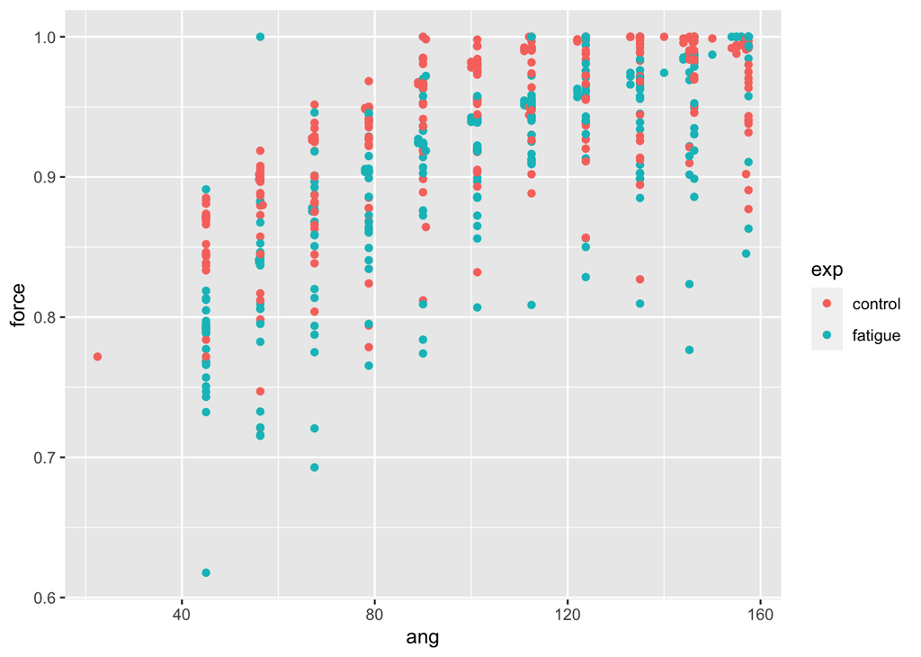

```r
dat.p2 %>%
  ggplot(aes(ang,force,col=exp))+geom_point() #visualize
```

*Figure 1. Visualization of the normalized force-length relationship data of contorl and fatigue groups*

Model prediction filtered by best fit through the AIC analysis is shown below.

```r
best.models <- fits%>%
  left_join(AICs)%>%
  group_by(subject,exp)%>%
  mutate(best=AICc==min(AICc))%>%
  filter(best==TRUE)%>%
  dplyr::select(-best)%>%
  print()
```

```
## # A tibble: 54 × 5
## # Groups:   subject, exp [54]
##    subject exp     model theta_max   AICc
##    <chr>   <chr>   <chr>     <dbl>  <dbl>
##  1 1       control m2         135. -130.
##  2 1       fatigue m3         158.  -94.2
##  3 10      control m2         136.  -70.1
##  4 10      fatigue m3         158.  -53.9
##  5 14      control m2         136. -115.
##  6 14      fatigue m3         158.  -75.7
##  7 17      control m2         125.  -37.7
##  8 17      fatigue m2         141.  -30.0
##  9 18      control m2         152.  -21.1
## 10 18      fatigue m2         112.  -27.8
## # … with 44 more rows
```

ANOVA for theta_max in fatigue and control conditions for the best model was then produced.

```r
anova(lm(theta_max~exp,best.models))
```

```
## Analysis of Variance Table
##
## Response: theta_max
##           Df Sum Sq Mean Sq F value   Pr(>F)
## exp        1 1428.0 1428.03  8.6933 0.004775 **
## Residuals 52 8541.9  164.27
## ---
## Signif. codes:  0 '***' 0.001 '**' 0.01 '*' 0.05 '.' 0.1 ' ' 1
```

Finally, the average difference between the control and fatigue group was calculated to derived the mean shift with SEM

```r
best.models%>%
  pivot_wider(id_cols=subject,names_from = exp,values_from=theta_max)%>%
  mutate(shift=fatigue-control) %>%
  ungroup() %>%
  na.omit() %>%
  summarise(mean.shift=mean(shift),se.shift=sd(shift)/sqrt(length(shift)))
```

```
## # A tibble: 1 × 2
##   mean.shift se.shift
##        <dbl>    <dbl>
## 1       10.9     4.14
```

# Discussion

The class-wide force-angle data for isometric MVC does not appear to follow a typical FL relationship under both control and fatigued conditions. A typical FL relationship posits that muscles generate the greatest force when at their ideal length and the least amount of force when shortened or stretched relative to the resting length. As such, at extreme angle values, a decrease in output force would be expected. However, with the class wide data, it appears that force steadily increases after an angle of 40 degrees, hits a max at around 110 degrees, and plateaus between 110 degrees and 160 degrees. In a typical FL relationship, as discussed by (Rassier, MacIntosh, and Herzog (1999)), force should increase, plateau, and then drop off after the ideal angle is reached, but this was not the case with the class wide data.

A possible source of error that may explain the discrepancy between the predicted result and the experimental result is that, if the data was collected consecutive from the greatest possible angle (157.5) to the lowest angle (45) for each subjects, the muscles would be be already fatigued once the muscle reached the “ideal” length to provide maximum output. This would result in minimal difference between the force output at high angle compared to the ideal moderate angle resulting in the plateau shape that was observed in the experimental data.

# Author Contribution

Tingwei Hu - Setup, read files, plot initial data, data analysis code in methods and results

Justin Lau - Discussion

Liz Asprinio - Introduction, Discussion, References

Jinseo Kim - Methods, Results, Discussion, and Formatting

## CPK comments

Really great job tying all this together. My only critique is that the tables could have been rendered more neatly, i.e., not just a tibble (-2).

73/75

# References

Rassier, Dilson E, BR MacIntosh, and W Herzog. 1999. “Length Dependence of Active Force Production in Skeletal Muscle.” *Journal of Applied Physiology* 86 (5): 1445–57.